# Simulating and breaking the Monty Hall Problem

Sean Maden

2/3/2020

On a gameshow stage before you wait three closed doors, behind which have been deposited 2 goats and one prize, respectively. You are called on to pick a door to open and reveal either a goat or a prize. Monty Hall, the gameshow’s host, proceeds to reveal a goat behind one of the two unpicked doors. You must then decide whether to stick with your original choice or switch to the final unpicked door. What do you do?

This is the [Monty Hall Problem](https://en.wikipedia.org/wiki/Monty_Hall_problem), a kind of logic puzzle involving conditional probability. Assuming you value prizes over goats, it can be readily shown that you should *always* switch whichever door you’ve initially picked to maximize your success probability. If you stick with your first choice, your success probability never exceeds 1 out of 3 tries, while switching increases your probability to 2 out of 3, a pretty substantial increase!

It’s telling that the Monty Hall Problem still serves as a good brain teaser to this day. Given its simple rules and decision parameters, it’s a problem that lends itself to programmatic simulation. I wrote a script to allow exploration of this problem. The full code with plotting utilities is available at the project’s GitHub repo. We can use this simulation to illustrate some features and ways of thinking about the problem, including better ways of intuiting the answer should we forget!

# The simulation function

The simulation function, `runmh()`, runs iterations of the Monty Hall problem with various allowances for changing underlying parameters. I wrote the function to allow for tweaking the underlying rules of the problem, which I explore below. Running it with default parameters is equivalent to what I’ll call the “canonical/classic” formulation of the Monty Hall Problem, which has the following rules:

1. Three doors total, behind which 1 has a prize, and the remaining 2 have goats.
2. The player picks a door.
3. Monty reveals one of the two remaining doors to be a goat.
4. The player decides whether to stick with their initial choice (step 2) or switch to the last unpicked door.
5. The final player-selected door is revealed to be either a goat or the prize.

The arguments `niter` and `seed` are important to consider even when running the simulation function with defaults otherwise. The `niter` argument specifies the number of game iterations to simulate, while setting `seed` specifies the value passed to `set.seed()`. Setting the seed allows for *exact* replication of run results with the same seed, an important component for operations implementing randomness. As already mentioned, the simulation assumes random player selection in step 2 and Monty selection in step 3, with other possibilities for randomness including the player door switch frequency in step 4. I implemented randomization with the `sample` R function.

Formally, each game simulation (up to `niter` total simulations per run) is run in a `for` loop. This could potentially be improved with parallelization and multithreading as with the [`pools`](https://cran.r-project.org/web/packages/pool/index.html) or [snow](https://cran.r-project.org/web/packages/snow/index.html) R packages, though there’s a bit of a tradeoff. However convenient parallelization is made with specilized packages, this implies adding an extra dependency to the package and a bit more code. If the problem in question were considerably more memory taxing than the Monty Hall problem, this could justify parallelization. Another consideration is that parallelization typically breaks strict replicability of a task, since sub-tasks or jobs are returned as they finish in a non-determined fashion. Here, this means the outcome of each game simulation would change with parallelization. This point is somewhat moot because here we’re primarily interested in the win fraction, but this could be important in other settings.

Let’s break down how the phases of the game are encoded within each iteration. First, the index of the prize door is specified.

```r
which.prize <- sample(doorseq, nprize)
```

The player’s first decision is then simulated.

```r
dec1select <- sample(doorseq, ndec1)
```

Monty then reveals a goat. He does so either by picking between two goat-doors at random (e.g. if the player already selected the prize-door, an unlikely event), or simply picking the last remaining door with a goat (e.g. if the player picked a goat-door, a likely event).

```r
mdooroptions <- doorremain1[!doorremain1 %in% which.prize]
if(length(mdooroptions) < 2){
  mselect <- mdooroptions
} else{
  mselect <- sample(mdooroptions, nr)
}
```

We check that the number of remaining “non-revealed” doors specified by `nrevealdif` is valid for the problem, then proceed to either specify a random set ofdoor indices to reveal or the only remaining valid door.

Next, the player either switches or stays on their initial door selection. Note how switch frequency from `doorswitch` impacts the likelihood of passing `switch` or `stay` to `ssvar`.

```r
doorexclude2 <- c(mselect, dec1select)
doorremain2 <- doorseq[!doorseq %in% doorexclude2]
# parse switch likelihood
switchassess <- "switch"
if(is.numeric(doorswitch) & doorswitch >= 0 & doorswitch <= 1){
  ssvar <- ifelse(doorswitch == 1, "switch",
         sample(c(rep("switch", doorswitch),
                  rep("stay", 100 - doorswitch)), 1))
} else{
  stop("Invalid doorswitch value.")
}

if(ssvar == "switch"){
  if(length(doorremain2) > 1){
    dec2select <- sample(doorremain2, ndec2)
  } else{
    dec2select <- doorremain2
  }
} else{
  dec2select <- dec1select
}
```

The function then returns a vector of game outcomes (either `win` or `loss`) of length equal to `niter`. I’ve also included a `verbose.results` option that stores the granual game details for each iteration alongside outcome. I mainly used this for bug squashing.

# Simulating the canonical/classic problem

We’ll start small by running just 5 simulations, each consisting of 2 game iterations. Since we’ll be doing a few of these runs, we’ll wrap operations into a function `getfw` and store our results. Our seed will simply be a sequence from 1 to `nsimulations` in each run.

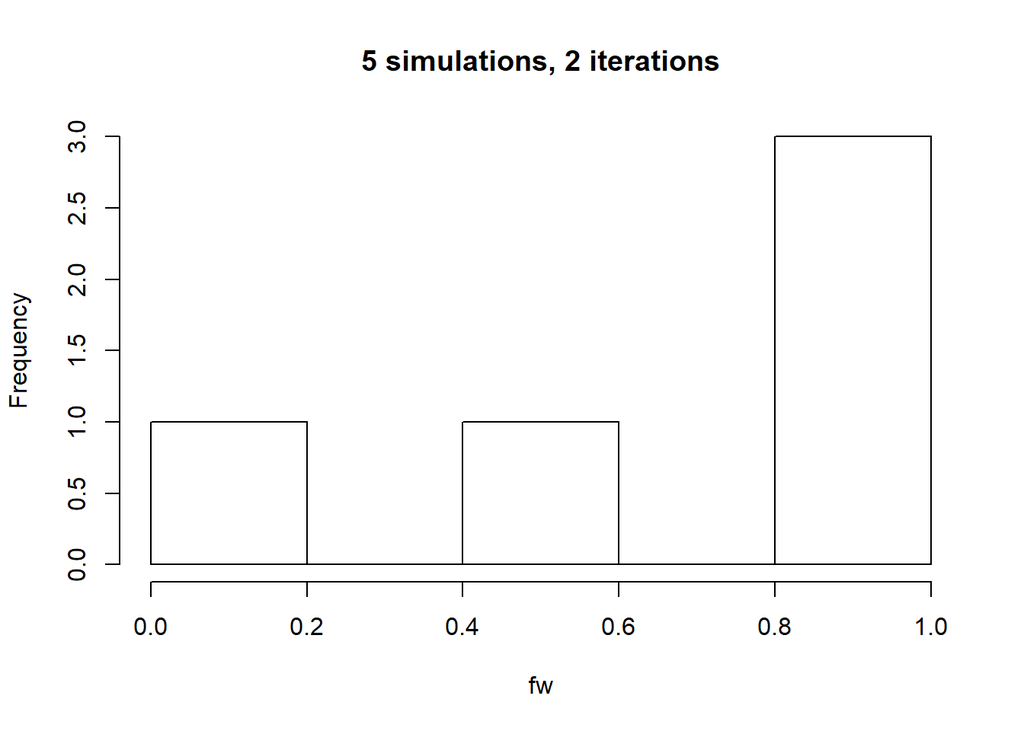

```r
# run simulation
simi <- 5; iteri <- 2
lr <- list()
fw <- getfw()
lr[[paste0(simi, ";", iteri)]] <- fw
# make win frequency histogram
hist(fw, main = paste0(simi," simulations, ", iteri, " iterations"))
```

With so few iterations and simulations overall, there’s huge variance in the win fraction (x-axis, above). Increasing iterations and simulations each to 100 already shows the distribution converging on the expected win frequency of 0.66.

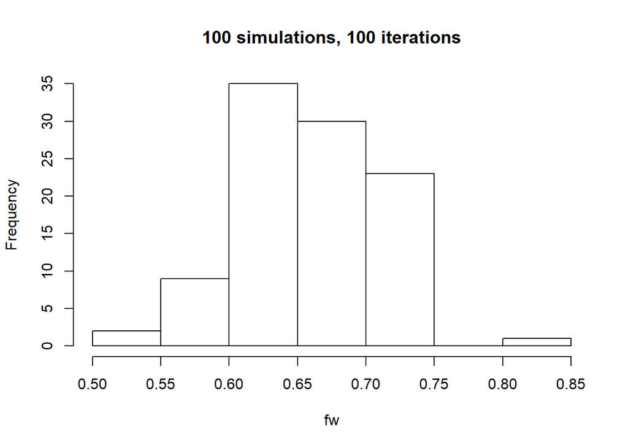

```r
# run simulation
simi <- 100; iteri <- 100
fw <- getfw(simi, iteri)
lr[[paste0(simi, ";", iteri)]] <- fw
# make win frequency histogram
hist(fw, main = paste0(simi," simulations, ", iteri, " iterations"))
```

Further increase to 1,000 simulations and iterations results in a more clearly normal distribution with much tighter standard deviation.

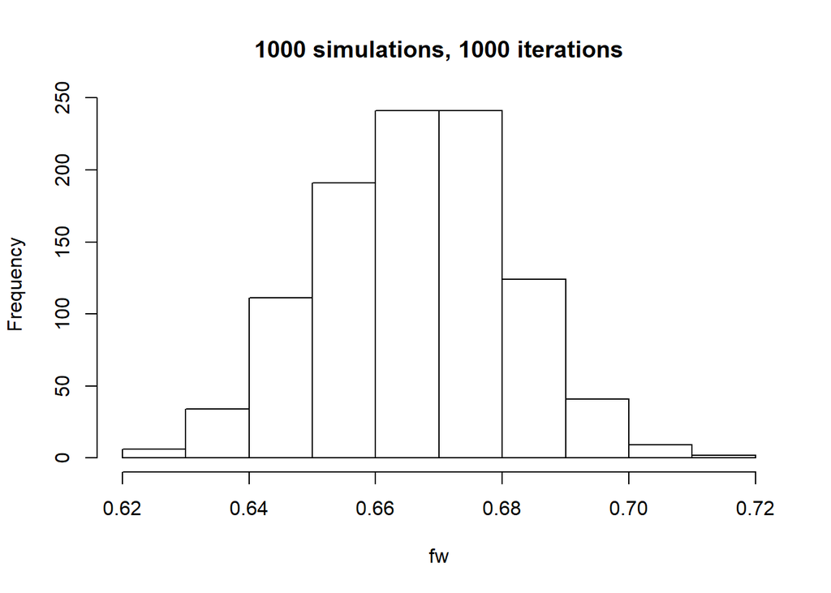

```r
# run simulation
simi <- 1000; iteri <- 1000
t1 <- Sys.time()
fw <- getfw(simi, iteri)
tdif <- t1 - Sys.time()
lr[[paste0(simi, ";", iteri)]] <- fw
# make win frequency histogram
hist(fw, main = paste0(simi," simulations, ", iteri, " iterations"))
```

This completes in roughly 20 seconds to boot. If you prefer to be more precise about the increase in normalcy, we can show greater distribution normalcy by high confidence from the [Shapiro-Wilk Normality test](https://en.wikipedia.org/wiki/Shapiro%E2%80%93Wilk_test) with `shapiro.test`, where we test the null hypothesis that data were drawn from a normal distribution.

```r
# run normalcy tests
shapiro.test(lr[["5;2"]])$p.value
```

```
## [1] 0.04595432
```

```r
shapiro.test(lr[["100;100"]])$p.value
```

```
## [1] 0.4310923
```

```r
shapiro.test(lr[["1000;1000"]])$p.value
```

```
## [1] 0.5809776
```

With increased simulations and iterations, our p-value increase. This increase means decreased confidence in our alternative hypothesis (non-normalcy) due to the underlying convergence of results on a normal distribution.

# Bending the rules

Bending the rules of the Monty Hall Problem can help to better understand the problem in a few ways. Below, I explain the utility of increasing the door quantity to intuit that switching is *always* better than staying on the same door, under the original rules. I also explore how changing certain underlying rules impacts game win frequencies.

# The “many doors” extrapolation mnemonic

One of the more useful [mnemonic devices](https://en.wikipedia.org/wiki/Mnemonic) I’ve encountered for intuiting the answer to the Monty Hall Problem is to increase the number of doors. Maybe we’re unsure if switching doors will increase our odds when there are just 3 doors. But if there are 100 doors and Monty reveals goats behind 98 of them, it’s much clearer that switching will increase our odds.

With the simulation code, we can readily visualize the effect of increasing door quantity on our win odds if we always switch. Below, I store the results of running 100 simulations with 100 iterations each, where each test includes total doors ranging from 3 to 100.

```r
# get win frequencies from varying ndoors
simi = 100; iteri = 100
ndoorl <- seq(3, 103, 10)
seedl <- seq(1, 100, 1)
lnd <- list()
t1 <- Sys.time()
for(nd in ndoorl){
  fw <- getfw(simi, iteri, nd)
  lnd[[paste0(nd)]] <- fw
}
tdif <- Sys.time() - t1
# store the reference plot
pref <- getlineplot(lnd, ptitle = "Canonical rules, varying doors")
```

This completes in 4.793 seconds. We can then view the results in a few types of useful visualizations, including violin plots, ridge density plots, and a line plot showing the min, mean, and max win fractions by door quantities. I’ve wrapped the code to accomplish this in a function, `getprettyplots()`, but suffice to say I made good use of the super-useful [`ggplot2`](https://cran.r-project.org/web/packages/ggplot2/index.html), [`gridExtra`](https://cran.r-project.org/web/packages/gridExtra/index.html), and [`ggridges`](https://cran.r-project.org/web/packages/ggridges/index.html) R packages.

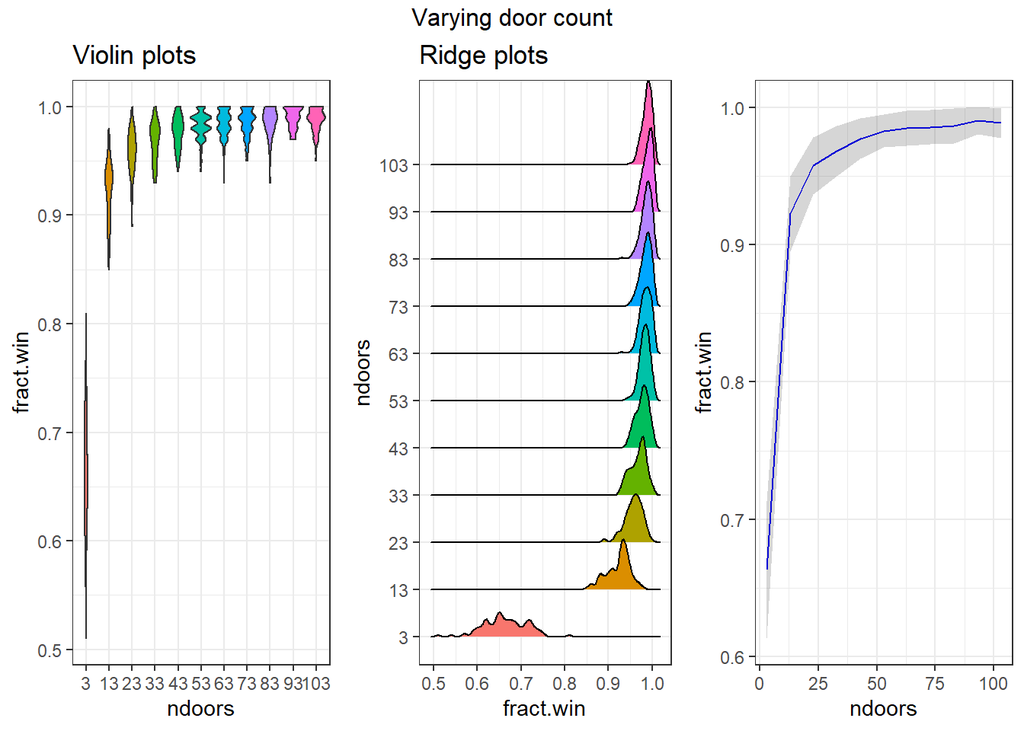

```r
getprettyplots(lnd, "Varying door count")
```

Something interesting these plots make clear is that the mean of win fractions converges before the standard deviation. Also clear is the visual contrast between win likelihood tendencies at the minimum (3) and maximum (100) door quantities. This is a quantitative way of showing the utility of the “many doors” extrapolation mnemonic. Below, I’ll assess changing other conditions across games with varying numbers of doors.

# What if prize placement isn’t random?

What if the prize is always behind door 1, while other conditions and assumptions are kept? That is, the player still selects a door at random (may they have amnesia, or it’s a new player every game?) and they always switch to the remaining door not revealed by Monty. We can set this up by simply specifying `prize.index = 1` and reruning simulation code as above.

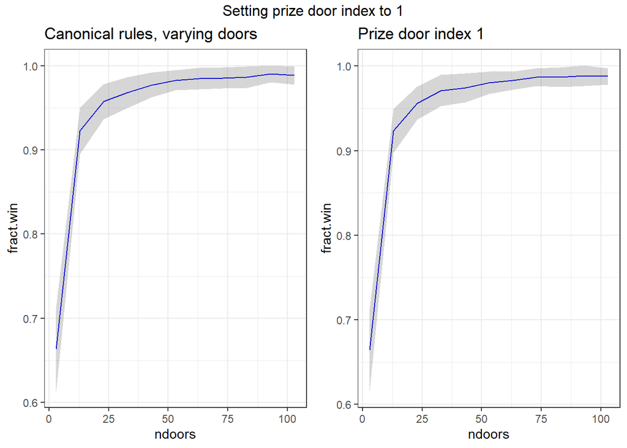

```r
# get fwin dist across ndoors
simi = 100; iteri = 100
ndoorl <- seq(3, 103, 10)
seedl <- seq(1, 100, 1)
lnd <- list()
for(nd in ndoorl){
  fw <- getfw(simi, iteri, nd, prize.index = 1)
  lnd[[paste0(nd)]] <- fw
}
ptest <- getlineplot(lnd, ptitle = "Prize door index 1")
# make composite with ref plot
grid.arrange(pref, ptest, ncol = 2, top = "Setting prize door index to 1")
```

We can compare results in the above composite of our reference plot with canonical rules and results from setting the prize door index to always be 1. It looks like there’s negigible impact to win frequency even when the prize position is not randomized.

# What if the player doesn’t always switch?

Let’s now test the impact of the player switch frequency, or the frequency with which a player will either switch doors or stay with their original selection. We can vary this frequency between 0 - 100, then reassess the win frequency distributions across games varying the numbers of doors.

```r
# get fwin dist across ndoors
plist <- list()
sfreq <- seq(0, 1, 0.1)
t1 <- Sys.time()
for(s in sfreq){
  simi = 100; iteri = 100
  ndoorl <- seq(3, 103, 10)
  seedl <- seq(1, 100, 1)
  lnd <- list()
  for(nd in ndoorl){
    fw <- getfw(simi, iteri, nd, doorswitch = s)
    lnd[[paste0(nd)]] <- fw
  }
  plist[[paste0(s)]] <- getlineplot(lnd, ptitle = paste0("S.F. = ", s),
                                    xlim = c(0, 100), ylim = c(0, 1))
  message(s)
}
```

```
## 0
```

```
## 0.1
```

```
## 0.2
```

```
## 0.3
```

```
## 0.4
```

```
## 0.5
```

```
## 0.6
```

```
## 0.7
```

```
## 0.8
```

```
## 0.9
```

```
## 1
```

```r
tdif <- Sys.time() - t1
```

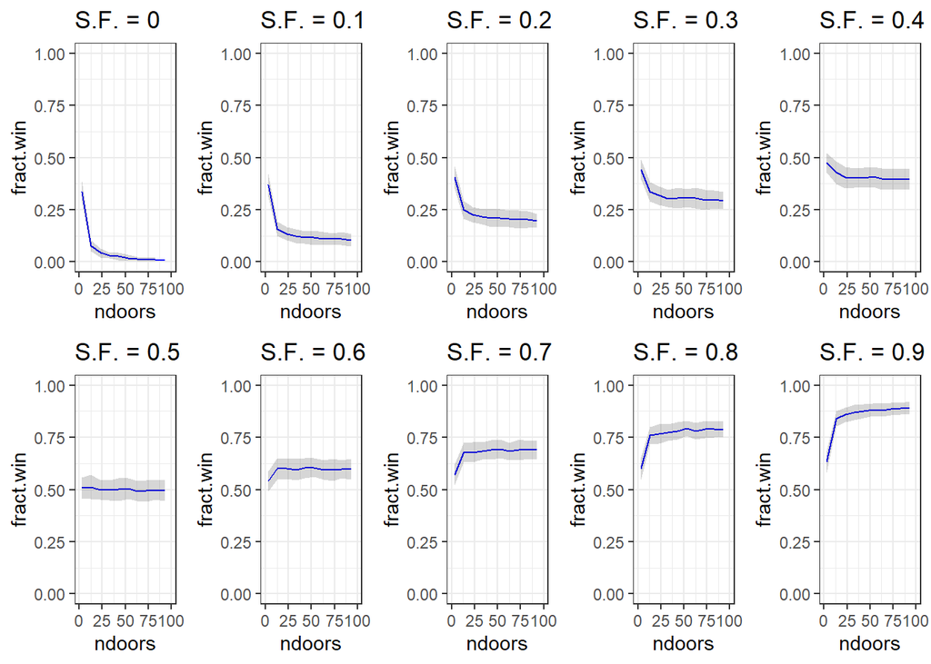

```r
grid.arrange(plist[[1]], plist[[2]], plist[[3]],
             plist[[4]], plist[[5]], plist[[6]],
             plist[[7]], plist[[8]], plist[[9]],
             plist[[10]],
             ncol = 5)
```

Finally, we can also show the line plot of win frequency change with player switch frequency using only the canonical rules set.

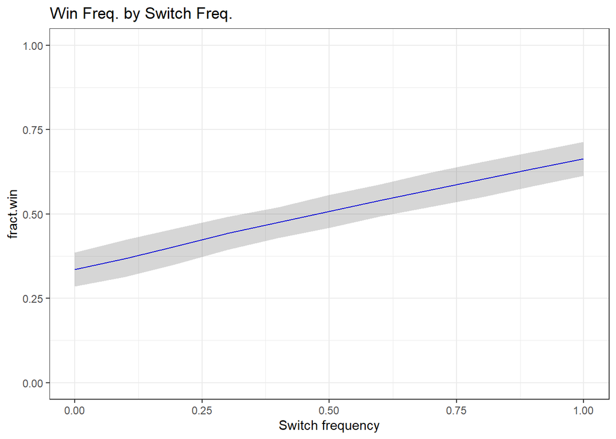

```r
sfreq <- seq(0, 1, 0.1)
t1 <- Sys.time()
lnd <- list()
for(s in sfreq){
  simi = 100; iteri = 100
  seedl <- seq(1, 100, 1)
  fw <- getfw(simi, iteri, doorswitch = s)
  lnd[[paste0(s)]] <- fw
}
getlineplot(lnd, ptitle = "Win Freq. by Switch Freq.",
            xlim = c(0, 1), ylim = c(0, 1),
            xlab = "Switch frequency")
```

That’s a pretty linear win fraction increase!